# R Notebook

### Introduction

Unmanned Aerial Vehicles (UAVs) play an important role in agricultural research because they facilitate high-throughput phenotyping (HTP).The ability to identify cotton plant height and boll count across a field can serve as an important tool in predicting plant growth and yield. In order to capture a three-dimensional (3D) view of field plots, which is believed to be helpful in estimating yield and crop development parameters, sensors mounted on UAVs must have access to a view of the ground. However, cotton planted in solid rows can obscure this view. Canopy closure prevents sensors from measuring plant architecture and boll-loads three dimensionally from the midgrowing season until the crop is defoliated. Therefore, this project was initiated to compare solid vs. skip-row planting patterns in terms of predicting yield and fiber quality since skip rows would allow UAV sensors to capture more accurate 3D data from plots. The purposes of this project were to (1) compare the accuracy of UAV-derived data from different row patterns (2) evaluate the ability of UAVs to predict plant yield and (3) characterize genotype x row pattern interaction and how location and year affect that interaction.

#### Objective 1: Accuracy between different row patterns

The height measured by UAV and human was compared.

```r
df <- read.csv("/Users/wenzhuowu/Desktop/tamu-project/height1.csv", header=TRUE)
head(df)
```

|  | ID | UAV_h | Manual_h | row_pattern |
| --- | --- | --- | --- | --- |
| 1 | UAV-101 | 23.08923 | 15.2 | solid |
| 2 | UAV-102 | 21.51380 | 15.2 | solid |
| 3 | UAV-103 | 22.51454 | 15.2 | solid |
| 4 | UAV-104 | 19.85056 | 15.6 | solid |
| 5 | UAV-105 | 19.08506 | 15.8 | solid |
| 6 | UAV-106 | 16.34745 | 14.8 | skip |

```r
lm1 = lm(UAV_h~Manual_h, data = df[df$row_pattern=='solid',]) #Create the linear regression
summary(lm1)
```

```
##
## Call:
## lm(formula = UAV_h ~ Manual_h, data = df[df$row_pattern == "solid",
##     ])
##
## Residuals:
##      Min       1Q   Median       3Q      Max
## -18.4786  -6.1179  -0.4783   5.0431  22.3615
##
## Coefficients:
##             Estimate Std. Error t value Pr(>|t|)
## (Intercept)  5.09666    2.41063   2.114   0.0361 *
## Manual_h     1.00389    0.04343  23.116   <2e-16 ***
## ---
## Signif. codes:  0 '***' 0.001 '**' 0.01 '*' 0.05 '.' 0.1 ' ' 1
##
## Residual standard error: 8.942 on 158 degrees of freedom
## Multiple R-squared:  0.7718, Adjusted R-squared:  0.7704
## F-statistic: 534.4 on 1 and 158 DF,  p-value: < 2.2e-16
```

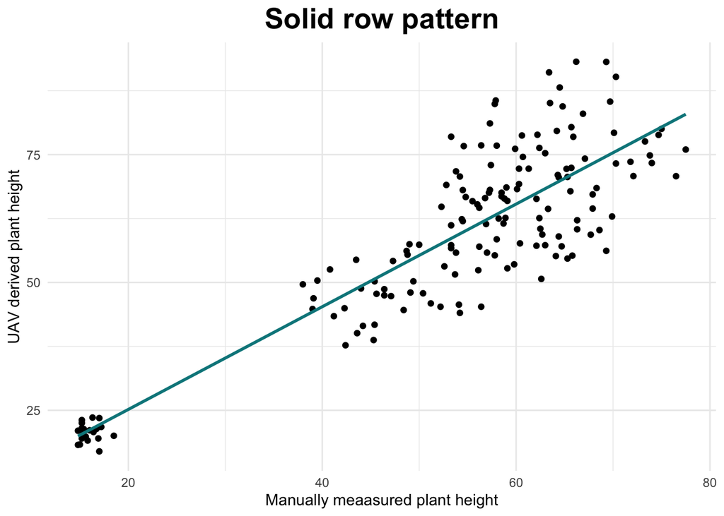

```r
library(ggplot2)


ggplot(df[df$row_pattern=='solid',],aes(Manual_h, UAV_h)) +
  geom_point() +
  geom_smooth(method='lm', se=FALSE, color='turquoise4') +
  theme_minimal() +
  labs(x='Manually meaasured plant height', y='UAV derived plant height', title='Solid row pattern') +
  theme(plot.title = element_text(hjust=0.5, size=20, face='bold'))
```

```r
lm2 = lm(UAV_h~Manual_h, data = df[df$row_pattern=='skip',]) #Create the linear regression
summary(lm2)
```

```
##
## Call:
## lm(formula = UAV_h ~ Manual_h, data = df[df$row_pattern == "skip",
##     ])
##
## Residuals:
##     Min      1Q  Median      3Q     Max
## -9.0509 -2.4258 -0.0081  2.6376 11.4343
##
## Coefficients:
##             Estimate Std. Error t value Pr(>|t|)
## (Intercept)  2.04025    0.81995   2.488   0.0139 *
## Manual_h     1.04166    0.01281  81.300   <2e-16 ***
## ---
## Signif. codes:  0 '***' 0.001 '**' 0.01 '*' 0.05 '.' 0.1 ' ' 1
##
## Residual standard error: 3.557 on 158 degrees of freedom
## Multiple R-squared:  0.9767, Adjusted R-squared:  0.9765
## F-statistic:  6610 on 1 and 158 DF,  p-value: < 2.2e-16
```

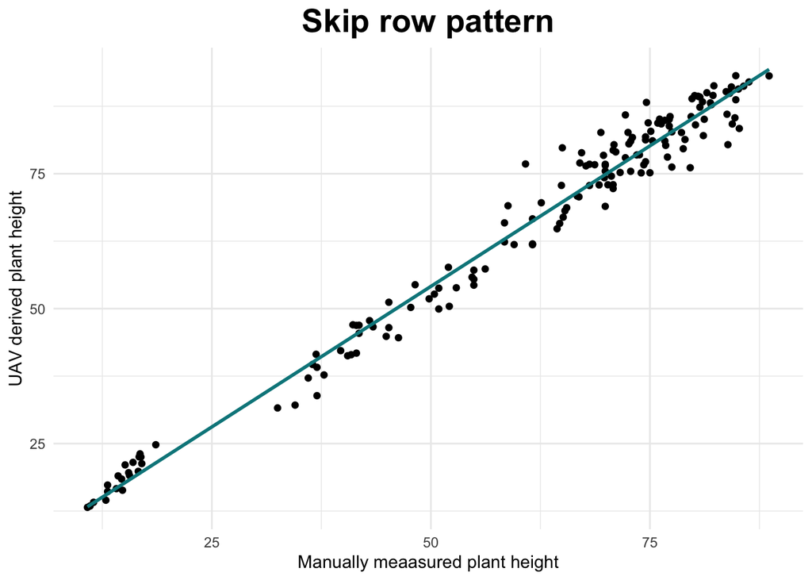

```r
ggplot(df[df$row_pattern=='skip',],aes(Manual_h, UAV_h)) +
  geom_point() +
  geom_smooth(method='lm', se=FALSE, color='turquoise4') +
  theme_minimal() +
  labs(x='Manually meaasured plant height', y='UAV derived plant height', title='Skip row pattern') +
  theme(plot.title = element_text(hjust=0.5, size=20, face='bold'))
```

The skip-row planting pattern provided a more accurate plant height (R2 0.97) with lower levels of error (RMSE 3.557) compared to data collected from the solid-row pattern (R2 0.77; RMSE 8.942 ). Row pattern may have an impact on the accuracy of plant height model based on UAV images.

#### Objective 2: Yield prediction

Plant height (ph), canopy colume (cv), canopy cover (cc), vegetation index NDVI, ExG were generated from UAV images across multiple dates. Boll count and boll area were processed based on the images taken the day before harvest.

```r
library(plyr)
library(readr)
library(dplyr)
library(glmnet)
library(ggplot2)
library(tidyverse)
library(caret)
library(leaps)
library(MASS)
```

```r
dat <- read.csv("/Users/wenzhuowu/Desktop/tamu-project/timeline.csv", header=TRUE)
dat = na.omit(dat)
head(dat)
```

|  | Yield.per.row | ph424 | ph514 | ph523 | ph601 | ph606 | ph613 | ph703 | ph710 | CV0423 | CV0514 | CV0523 | CV0601 | CV0606 | CV0613 | CV0703 | CV0709 | CV0719 | CV0730 | NDVI0423 | NDVI0507 | NDVI0514 | NDVI0523 | NDVI0601 | NDVI0606 | NDVI0613 | NDVI0627 | NDVI0703 | NDVI0709 | … |
| --- | --- | --- | --- | --- | --- | --- | --- | --- | --- | --- | --- | --- | --- | --- | --- | --- | --- | --- | --- | --- | --- | --- | --- | --- | --- | --- | --- | --- | --- | --- |
| 1 | 0.7238045 | 23.08923 | 54.43071 | 64.79951 | 85.08744 | 91.08666 | 88.13228 | 93.16466 | 93.13207 | 0.05260687 | 0.10427062 | 0.1506674 | 0.2135402 | 0.2493004 | 0.2199320 | 0.3768582 | 0.3786870 | 0.07653988 | 0.07887313 | 0.6414540 | 0.7310976 | 0.7623606 | 0.8141249 | 0.7782031 | 0.7955470 | 0.7708026 | 0.7638851 | 0.7683153 | 0.8042386 | … |
| 2 | 0.3695207 | 21.51380 | 46.89888 | 55.43674 | 70.71673 | 76.67001 | 72.95586 | 76.75417 | 79.63202 | 0.03991368 | 0.08894159 | 0.1169693 | 0.1546981 | 0.1876132 | 0.1550796 | 0.2875302 | 0.2777700 | 0.05695665 | 0.06087028 | 0.6358705 | 0.7211970 | 0.7511253 | 0.8157233 | 0.7561875 | 0.7837406 | 0.7498242 | 0.7598329 | 0.7469738 | 0.8138712 | … |
| 4 | 1.2001809 | 19.85056 | 50.22382 | 61.99820 | 78.50110 | 84.90621 | 81.10504 | 85.58314 | 90.20983 | 0.05190211 | 0.11518645 | 0.1530012 | 0.1871325 | 0.2056447 | 0.1674668 | 0.2609449 | 0.2894993 | 0.05601709 | 0.06626179 | 0.6441107 | 0.7301496 | 0.7707717 | 0.7962466 | 0.7445925 | 0.7486963 | 0.7340292 | 0.7252100 | 0.7187384 | 0.7620830 | … |
| 5 | 0.7492547 | 19.08506 | 37.71485 | 44.60903 | 62.36279 | 69.06843 | 65.89498 | 76.80755 | 80.37630 | 0.05275008 | 0.11075749 | 0.1477807 | 0.1879758 | 0.1953552 | 0.1661987 | 0.2943320 | 0.3203904 | 0.03871509 | 0.06586310 | 0.6307880 | 0.7184223 | 0.7598661 | 0.8073528 | 0.7381456 | 0.7380863 | 0.7344738 | 0.7474213 | 0.7449222 | 0.7946994 | … |
| 6 | 1.9610077 | 16.34745 | 33.87159 | 44.86051 | 68.70007 | 79.80380 | 76.99425 | 84.23135 | 82.85676 | 0.04507159 | 0.09966807 | 0.1750264 | 0.3154559 | 0.4023677 | 0.3920168 | 0.4941357 | 0.4734154 | 0.12047814 | 0.15051981 | 0.6322879 | 0.7236893 | 0.7476041 | 0.8168395 | 0.7948603 | 0.8116707 | 0.8154895 | 0.8097940 | 0.7770749 | 0.8437351 | … |
| 7 | 3.5050858 | 16.64369 | 41.53833 | 49.93660 | 70.85788 | 79.35865 | 76.11390 | 85.59826 | 83.38367 | 0.04816094 | 0.08630561 | 0.1701969 | 0.2768518 | 0.3715808 | 0.3433249 | 0.4713480 | 0.4951644 | 0.08770911 | 0.12912089 | 0.6066887 | 0.7267454 | 0.7460610 | 0.8138227 | 0.7774627 | 0.7859246 | 0.7855760 | 0.7854951 | 0.7608642 | 0.8126085 | … |

Data partition

```r
set.seed(100)

index = sample(1:nrow(dat), 0.8*nrow(dat))

train = dat[index,] # Create the training data
test = dat[-index,] # Create the test data
```

Scaling the Numeric Features

```r
cols = colnames(dat)[-1]
pre_proc_val <- preProcess(train[,cols], method = c("center", "scale"))

train[,cols] = predict(pre_proc_val, train[,cols])
test[,cols] = predict(pre_proc_val, test[,cols])
```

stepwise regression

```r
# Set seed for reproducibility
set.seed(123)
# Set up repeated k-fold cross-validation
train.control <- trainControl(method = "cv", number = 10)
# Train the model
step.model <- train(Yield.per.row ~., data = dat,
                    method = "leapBackward",
                    tuneGrid = data.frame(nvmax = 1:34),
                    trControl = train.control
                    )
step.model$results
```

|  | nvmax | RMSE | Rsquared | MAE | RMSESD | RsquaredSD | MAESD |
| --- | --- | --- | --- | --- | --- | --- | --- |
| 1 | 1 | 1.400055 | 0.3992414 | 1.064650 | 0.8376179 | 0.3492695 | 0.6223935 |
| 2 | 2 | 1.385521 | 0.4870007 | 1.080098 | 0.8495000 | 0.3629914 | 0.6267542 |
| 3 | 3 | 1.436567 | 0.4663273 | 1.151763 | 0.8626869 | 0.3751979 | 0.6411067 |
| 4 | 4 | 1.569099 | 0.4844410 | 1.243484 | 0.7925774 | 0.3119199 | 0.6152801 |
| 5 | 5 | 1.514464 | 0.4792848 | 1.211049 | 0.7992111 | 0.3666704 | 0.6833244 |
| 6 | 6 | 1.570626 | 0.5160313 | 1.280873 | 0.7727055 | 0.4021671 | 0.7221285 |
| 7 | 7 | 1.775937 | 0.4925244 | 1.419441 | 0.8865010 | 0.3815736 | 0.8434231 |
| 8 | 8 | 1.814445 | 0.4800011 | 1.483891 | 0.8076021 | 0.3886539 | 0.7492466 |
| 9 | 9 | 1.800514 | 0.4663535 | 1.473391 | 0.8456117 | 0.3680168 | 0.7362490 |
| 10 | 10 | 1.834484 | 0.4939171 | 1.434662 | 0.8973196 | 0.3665860 | 0.7425752 |

[output cut: 24 more lines]

```r
step.model$bestTune
```

|  | nvmax |
| --- | --- |
| 2 | 2 |

```r
summary(step.model$finalModel)
```

[output not shown]

```r
m1 = lm(Yield.per.row ~ CV0730+ NDVI0730,
   data = dat)
summary (m1)
```

```
##
## Call:
## lm(formula = Yield.per.row ~ CV0730 + NDVI0730, data = dat)
##
## Residuals:
##     Min      1Q  Median      3Q     Max
## -2.8961 -0.6319 -0.1257  0.5315  3.5594
##
## Coefficients:
##             Estimate Std. Error t value Pr(>|t|)
## (Intercept)  -36.773      9.088  -4.046 0.000273 ***
## CV0730        12.074      6.737   1.792 0.081773 .
## NDVI0730      67.037     16.719   4.010 0.000304 ***
## ---
## Signif. codes:  0 '***' 0.001 '**' 0.01 '*' 0.05 '.' 0.1 ' ' 1
##
## Residual standard error: 1.349 on 35 degrees of freedom
## Multiple R-squared:  0.5386, Adjusted R-squared:  0.5123
## F-statistic: 20.43 on 2 and 35 DF,  p-value: 1.321e-06
```

ridge

```r
cols_reg = colnames(dat)
dummies <- dummyVars(Yield.per.row ~ ., data = dat[,cols_reg])
train_dummies = predict(dummies, newdata = train[,cols_reg])
test_dummies = predict(dummies, newdata = test[,cols_reg])
```

```r
x = as.matrix(train_dummies)
y_train = train$Yield.per.row

x_test = as.matrix(test_dummies)
y_test = test$Yield.per.row

lambdas <- 10^seq(2, -3, by = -.1)
ridge_reg = glmnet(x, y_train, nlambda = 25, alpha = 0, family = 'gaussian', lambda = lambdas)
summary(ridge_reg)
```

```
##           Length Class     Mode
## a0          51   -none-    numeric
## beta      3519   dgCMatrix S4
## df          51   -none-    numeric
## dim          2   -none-    numeric
## lambda      51   -none-    numeric
## dev.ratio   51   -none-    numeric
## nulldev      1   -none-    numeric
## npasses      1   -none-    numeric
## jerr         1   -none-    numeric
## offset       1   -none-    logical
## call         7   -none-    call
## nobs         1   -none-    numeric
```

```r
cv_ridge <- cv.glmnet(x, y_train, alpha = 0, lambda = lambdas)
optimal_lambda <- cv_ridge$lambda.min
optimal_lambda
```

```
## [1] 0.02511886
```

```r
# Compute R^2 from true and predicted values
eval_results <- function(true, predicted, df) {
  SSE <- sum((predicted - true)^2)
  SST <- sum((true - mean(true))^2)
  R_square <- 1 - SSE / SST
  RMSE = sqrt(SSE/nrow(df))


  # Model performance metrics
data.frame(
  RMSE = RMSE,
  Rsquare = R_square
)

}

# Prediction and evaluation on train data
predictions_train <- predict(ridge_reg, s = optimal_lambda, newx = x)
eval_results(y_train, predictions_train, train)
```

| RMSE | Rsquare |
| --- | --- |
| 0.04156802 | 0.999493 |

```r
# Prediction and evaluation on test data
predictions_test <- predict(ridge_reg, s = optimal_lambda, newx = x_test)
eval_results(y_test, predictions_test, test)
```

| RMSE | Rsquare |
| --- | --- |
| 0.593154 | 0.9196201 |

Lasso

```r
lambdas <- 10^seq(2, -3, by = -.1)

# Setting alpha = 1 implements lasso regression
lasso_reg <- cv.glmnet(x, y_train, alpha = 1, lambda = lambdas, standardize = TRUE, nfolds = 5)

# Best
lambda_best <- lasso_reg$lambda.min
lambda_best
```

```
## [1] 0.001
```

The optimal lambda value is 0.001, we train the lasso model in the first line of code below. The second through fifth lines of code generate the predictions and print the evaluation metrics for both the training and test datasets.

```r
lasso_model <- glmnet(x, y_train, alpha = 1, lambda = lambda_best, standardize = TRUE)

predictions_train <- predict(lasso_model, s = lambda_best, newx = x)
eval_results(y_train, predictions_train, train)
```

| RMSE | Rsquare |
| --- | --- |
| 0.002541985 | 0.9999981 |

```r
predictions_test <- predict(lasso_model, s = lambda_best, newx = x_test)
eval_results(y_test, predictions_test, test)
```

| RMSE | Rsquare |
| --- | --- |
| 0.006445168 | 0.9999905 |

The above output shows that the RMSE and R-squared values on the training data are 0.0025 and 99.99 percent, respectively. The results on the test data are 0.0064 and 99.99 percent, respectively. Lasso regression can also be used for feature selection because the coeﬃcients of less important features are reduced to zero.

```r
# Set training control
train_cont <- trainControl(method = "repeatedcv",
                              number = 10,
                              repeats = 5,
                              search = "random",
                              verboseIter = TRUE)

# Train the model
elastic_reg <- train(Yield.per.row ~ .,
                           data = train,
                           method = "glmnet",
                           preProcess = c("center", "scale"),
                           tuneLength = 10,
                           trControl = train_cont)
```

```r
# Best tuning parameter
elastic_reg$bestTune
```

|  | alpha | lambda |
| --- | --- | --- |
| 10 | 0.7689969 | 0.0089959 |

```r
# Make predictions on training set
predictions_train <- predict(elastic_reg, x)
eval_results(y_train, predictions_train, train)
```

| RMSE | Rsquare |
| --- | --- |
| 0.05803351 | 0.9990117 |

```r
# Make predictions on test set
predictions_test <- predict(elastic_reg, x_test)
eval_results(y_test, predictions_test, test)
```

| RMSE | Rsquare |
| --- | --- |
| 0.08225816 | 0.9984541 |